# Stalker- GLM Analyses

Jocelyn Stalker

9/15/2021

We will be looking at factors affecting and factors being affected by the toxicity of two newts: the California Newt (*Taricha torosa*) and the Rough-skinned Newt (*Taricha granulosa*).

California Newt

Rough-skinned Newt

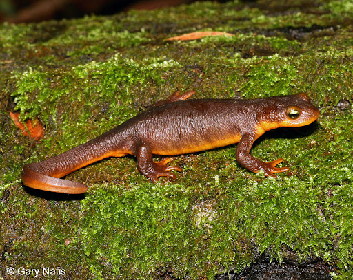

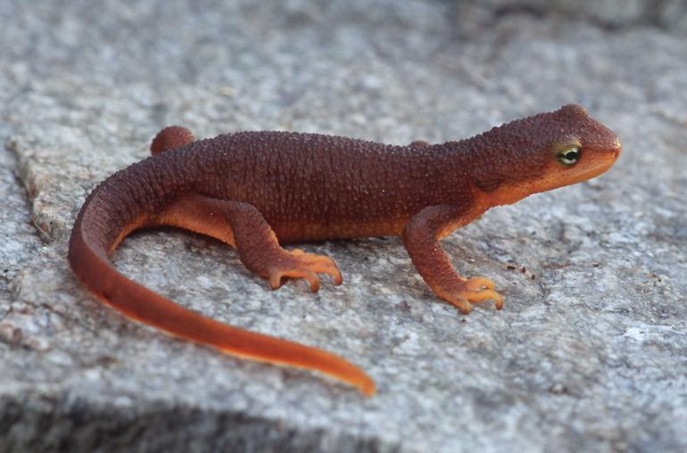

First, let’s import and tidy the data.

```r
data_newt <- read.csv("Data/newt_toxicity.csv", header=TRUE) %>% clean_names() %>% drop_na("ttx_cm2")
data_newt <- data_newt %>% add_column("p_count" = rowSums(data_newt[9:15]))
data_newt <- dplyr::select(data_newt, site, species, sex, svl, bd_poz, ttx_cm2, p_count)
```

Let’s make a plot to help visualize the impact of toxicity on the number of parasites/diseases found on each newt.

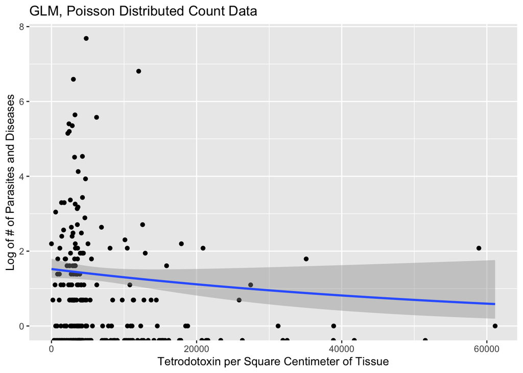

```r
ggplot(data_newt, aes(ttx_cm2, log(p_count))) + geom_point() +
  geom_smooth(method = glm, method.args = list(family = poisson(link = "log"))) +
  labs(title="GLM, Poisson Distributed Count Data") +
  xlab ("Tetrodotoxin per Square Centimeter of Tissue") +
  ylab ("Log of # of Parasites and Diseases")
```

The y-axis is log-transformed so that we can more clearly see the relationship between toxicity and parasite counts.

Let’s check assumptions.

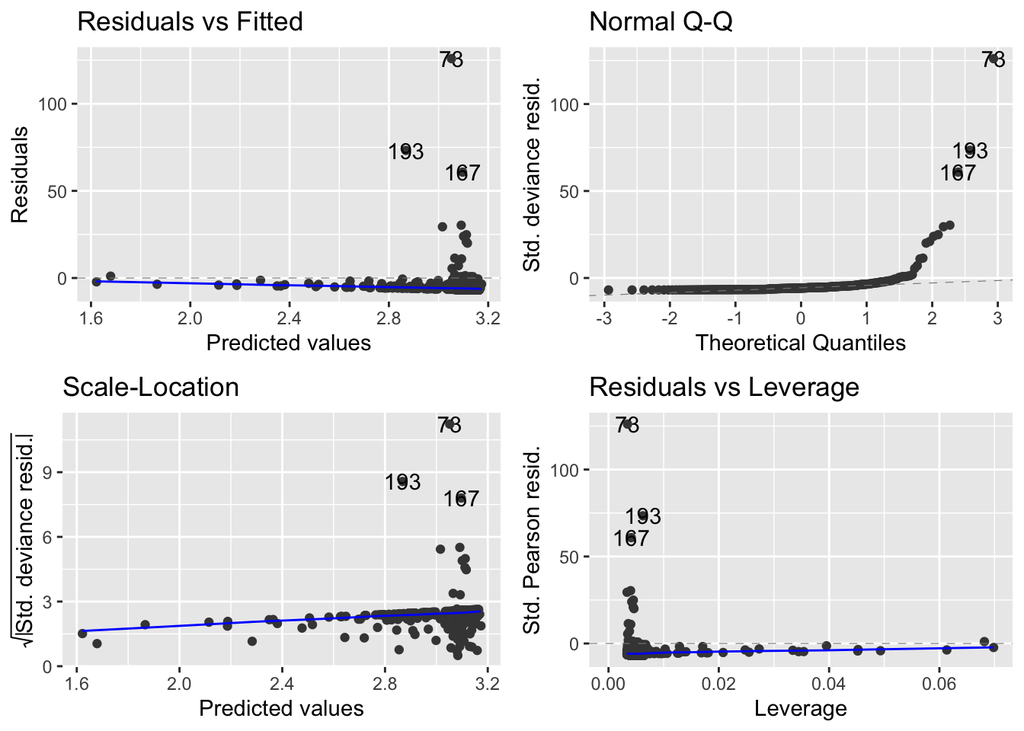

```r
newt.glm.p <- glm(p_count ~ ttx_cm2, data = data_newt, family = poisson(link = log))
autoplot(newt.glm.p)
```

The autoplot shows us that there are three points which are raising concerns, but we are not yet equipped to interpret this and make an alternative decision, so… onward!

```r
summary(newt.glm.p)
```

```
##
## Call:
## glm(formula = p_count ~ ttx_cm2, family = poisson(link = log),
##     data = data_newt)
##
## Deviance Residuals:
##     Min       1Q   Median       3Q      Max
##  -6.881   -6.572   -5.800   -4.686  125.876
##
## Coefficients:
##               Estimate Std. Error z value Pr(>|z|)
## (Intercept)  3.173e+00  1.699e-02  186.81   <2e-16 ***
## ttx_cm2     -2.537e-05  2.093e-06  -12.12   <2e-16 ***
## ---
## Signif. codes:  0 '***' 0.001 '**' 0.01 '*' 0.05 '.' 0.1 ' ' 1
##
## (Dispersion parameter for poisson family taken to be 1)
##
##     Null deviance: 38193  on 300  degrees of freedom
## Residual deviance: 38010  on 299  degrees of freedom
## AIC: 38559
##
## Number of Fisher Scoring iterations: 9
```

This model is highly overdispersed (38010>299), so let’s try a quasipoisson.

```r
newt.glm.qp <- glm(p_count ~ ttx_cm2, data = data_newt, family = quasipoisson(link = log))
summary(newt.glm.qp)
```

```
##
## Call:
## glm(formula = p_count ~ ttx_cm2, family = quasipoisson(link = log),
##     data = data_newt)
##
## Deviance Residuals:
##     Min       1Q   Median       3Q      Max
##  -6.881   -6.572   -5.800   -4.686  125.876
##
## Coefficients:
##               Estimate Std. Error t value Pr(>|t|)
## (Intercept)  3.173e+00  5.412e-01   5.863  1.2e-08 ***
## ttx_cm2     -2.537e-05  6.667e-05  -0.381    0.704
## ---
## Signif. codes:  0 '***' 0.001 '**' 0.01 '*' 0.05 '.' 0.1 ' ' 1
##
## (Dispersion parameter for quasipoisson family taken to be 1015.077)
##
##     Null deviance: 38193  on 300  degrees of freedom
## Residual deviance: 38010  on 299  degrees of freedom
## AIC: NA
##
## Number of Fisher Scoring iterations: 9
```

Running a quasipoisson changed the p-value from highly significant to insignificant.

Let’s turn these estimates into something that is easier to interpret. How many parasites and diseases would we expect a newt with 10,000 tetrodotoxin per cm2 to have? What about 30,000, or 50,000?.

```r
exp(3.173 + -2.537e-05*10000)
```

```
## [1] 18.52831
```

```r
exp(3.173 + -2.537e-05*30000)
```

```
## [1] 11.15514
```

```r
exp(3.173 + -2.537e-05*50000)
```

```
## [1] 6.716049
```

```r
anova(newt.glm.qp)
```

```
## Analysis of Deviance Table
##
## Model: quasipoisson, link: log
##
## Response: p_count
##
## Terms added sequentially (first to last)
##
##
##         Df Deviance Resid. Df Resid. Dev
## NULL                      300      38193
## ttx_cm2  1   183.12       299      38010
```

We can see that much of the deviance is not explained by the toxicity.

```r
coef(newt.glm.qp)
```

```
##   (Intercept)       ttx_cm2
##  3.173460e+00 -2.537194e-05
```

```r
confint(newt.glm.qp)
```

```
##                     2.5 %       97.5 %
## (Intercept)  2.0356399349 4.218223e+00
## ttx_cm2     -0.0002261863 5.684158e-05
```

And there you have the confidence intervals. Let’s move on to analyzing the impact of toxicity on presence/absence of a chytrid fungus. First, let’s visualize the data with a plot.

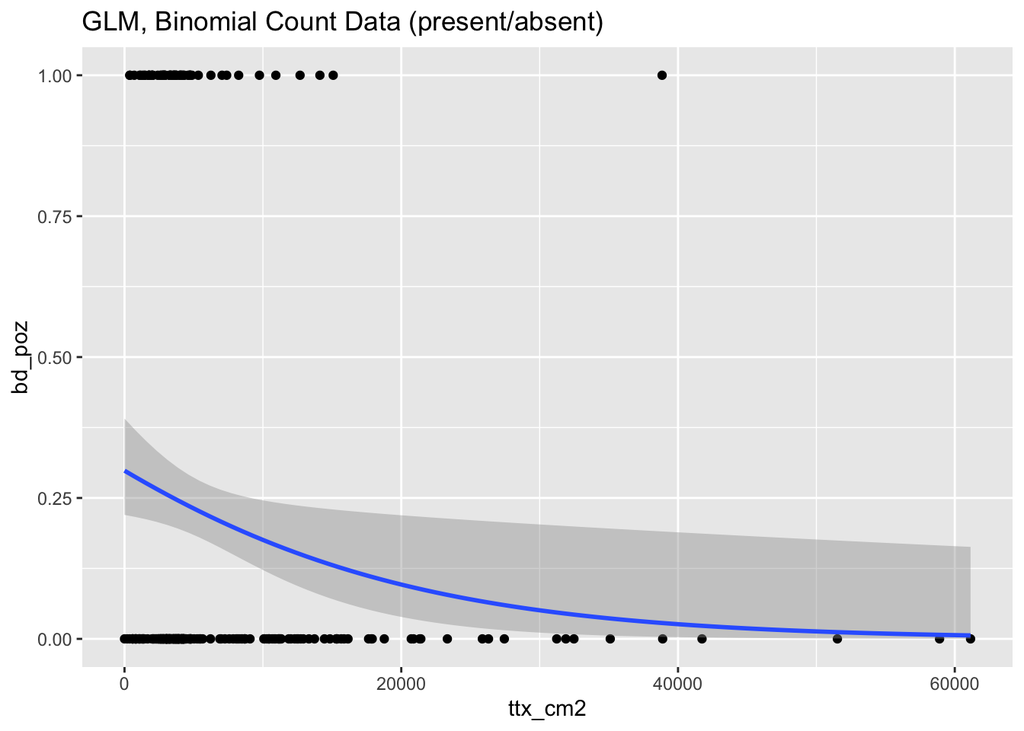

```r
ggplot(data_newt, aes(ttx_cm2, bd_poz)) +
  geom_point() +
  geom_smooth(method="glm", method.args=list(family="binomial"(link="logit"))) +
  labs(title="GLM, Binomial Count Data (present/absent)") + ylim(0,1)
```

Looks like there might be a relationship! Let’s build a model.

```r
newt_glm_b <- glm(bd_poz ~ ttx_cm2, data= data_newt, family= binomial(link= logit))
summary(newt_glm_b)
```

```
##
## Call:
## glm(formula = bd_poz ~ ttx_cm2, family = binomial(link = logit),
##     data = data_newt)
##
## Deviance Residuals:
##     Min       1Q   Median       3Q      Max
## -0.8419  -0.7650  -0.7307  -0.3044   2.6721
##
## Coefficients:
##               Estimate Std. Error z value Pr(>|z|)
## (Intercept) -8.548e-01  2.097e-01  -4.076 4.59e-05 ***
## ttx_cm2     -6.916e-05  3.115e-05  -2.220   0.0264 *
## ---
## Signif. codes:  0 '***' 0.001 '**' 0.01 '*' 0.05 '.' 0.1 ' ' 1
##
## (Dispersion parameter for binomial family taken to be 1)
##
##     Null deviance: 295.07  on 277  degrees of freedom
## Residual deviance: 287.46  on 276  degrees of freedom
##   (23 observations deleted due to missingness)
## AIC: 291.46
##
## Number of Fisher Scoring iterations: 5
```

So far, so good. It looks like the relationship is significant. Let’s make a binned residual plot to confirm that our data is dispersed well.

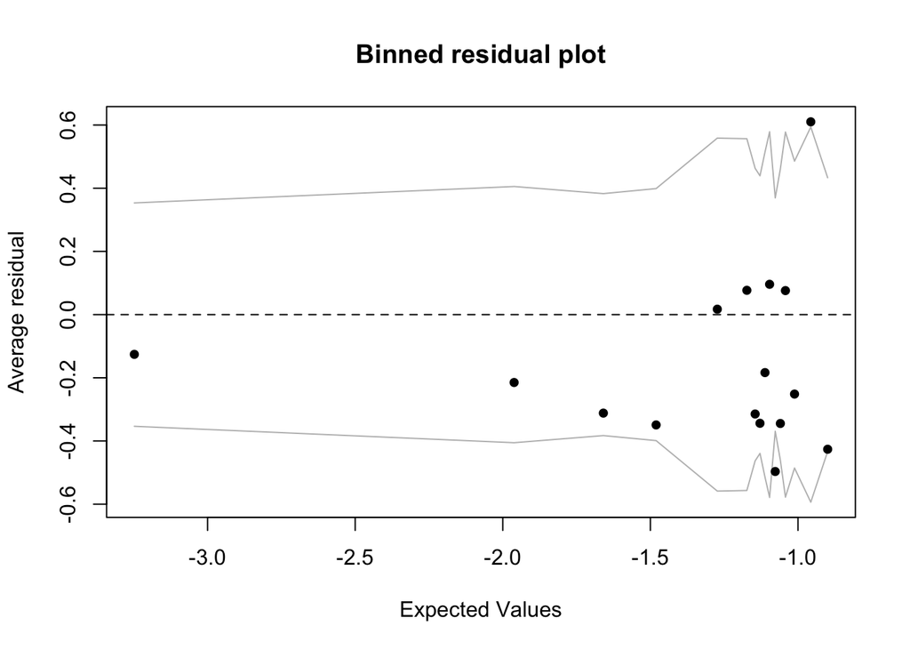

```r
x <- predict(newt_glm_b)
y <- resid(newt_glm_b)
binnedplot(x, y)
```

Looks good enough!

```r
coef(newt_glm_b)
```

```
##   (Intercept)       ttx_cm2
## -8.548437e-01 -6.915677e-05
```

```r
confint(newt_glm_b)
```

```
##                     2.5 %        97.5 %
## (Intercept) -1.2620960553 -4.378884e-01
## ttx_cm2     -0.0001392465 -1.687664e-05
```

Now that we have our confidence intervals, let’s again make this easier to interpret.

```r
(-6.916e-05/4)*1000
```

```
## [1] -0.01729
```

```r
`invlogit`(coef(newt_glm_b)[1] + coef(newt_glm_b)[2]*mean(data_newt$ttx_cm2))
```

```
## (Intercept)
##    0.211202
```

So, at the mean toxicity, there is about a 20% chance that a newt has Chytrid. For every 1,000 ttx/cm2 increase in toxicity, the probability of having Chytrid goes down by about 1.7%.

Stay toxic, friends.

[figure not shown]